# Tutorial - Violin + Box Plot

Isabella Bicalho Frazeto

9/6/2021

# Introdução

Esse mini-tutorial visa ensinar a como plotar box plot e o violin plot no mesmo gráfico usando o ggplot2. Nas sessões 1 e 2 mostramos o que é um box plot e um violin plot e discutimos um pouco sobre suas vantagens. Na sessão três, mostramos como plotar os dois juntos.

## Box plot

Boxplot, diagrama de caixa, ou diagrama de quartis, ou meu favorito, gráfico de caixa de bigodes, é um gráfico que permite visualizar como o seu conjunto de dados está distribuído. É um gráfico clássico em que mediana é o centro da caixa e o primeiro quartil e o terceiro formam o retângulo. Por último, bigodes da caixa são formados pelo limite inferior e o limite superior. Tipicamente, os outliers são representados por pequenos pontos no gráfico. Do wikipedia:

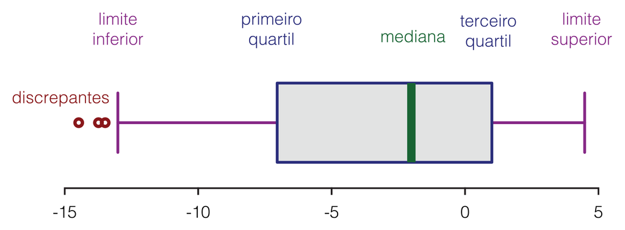

Por CEPID NeuroMat, CC BY-SA 4.0, https://commons.wikimedia.org/w/index.php?curid=56047497

## Violin plot

Violin plot é uma visualização similar a um box plot, porém ela tem a vantagem de usar um kernel de densidade simétrico em cada lado. Ou seja, ela também consegue refletir a densidade de probabilidade (ou em outras palavras, aquela linha que costuma estar cima dos histogramas). A maior vantagem é que ela consegue ser mais informativa que um simples diagrama de caixa porque ela mostra o seu conjunto inteiro de dados. Infelizmente, não é um gráfico tão popular o que pode gerar um pouco de confusão sobre sua interpretação. Também do wikipedia:

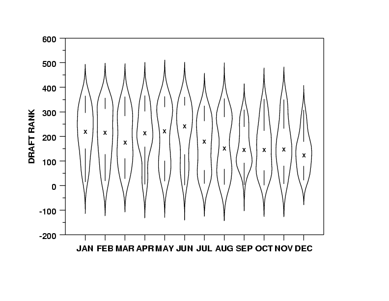

Por itl.nist.gov - VIOLIN PLOT at www.itl.nist.gov, Public Domain, https://commons.wikimedia.org/w/index.php?curid=4992563

## Por que usar ambos juntos?

O pulo do gato é que você plotar ambos no mesmo gráfico. Esse reflexo é especialmente importante se seus dados são multimodais porque isso fica evidente usando o violin plot e não é claro no box plot. Outra vantagem é que isso evita também que você acabe com um box plot, um histograma + estimativa de densidade kernel para cada variável. Pela própria natureza dos gráficos, é também mais fácil de visualizar a sua amostra por fatores diferentes.

## Tutorial

```r
library(datasets)
library(ggplot2)

data("PlantGrowth")
data("InsectSprays")

head(PlantGrowth)
```

```
##   weight group
## 1   4.17  ctrl
## 2   5.58  ctrl
## 3   5.18  ctrl
## 4   6.11  ctrl
## 5   4.50  ctrl
## 6   4.61  ctrl
```

Insect Sprays é o resultado de um experimento que visava saber qual seria o spray mais efetivo. Possui duas colunas: count (quantidade) e spray.

```r
head(InsectSprays)
```

```
##   count spray
## 1    10     A
## 2     7     A
## 3    20     A
## 4    14     A
## 5    14     A
## 6    12     A
```

## PlantGrowth

Usando ggplot2, você pode plotar dois gráficos diretamente usando apenas “somando” dois objetos geométricos diferentes, mas o resultado não é muito simpático.

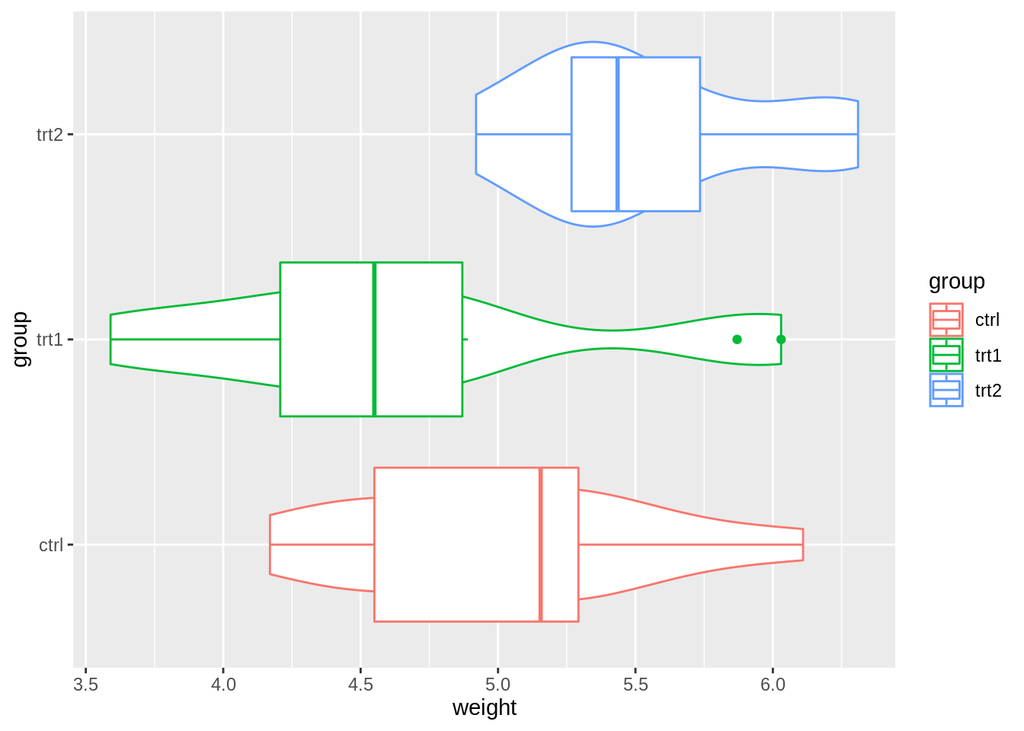

```r
ggplot(PlantGrowth, aes(x=weight, y=group, color = group)) +
        geom_violin() +
        geom_boxplot()
```

O primeiro passo é mudar a largura dos boxplots. Para isso, passamos o width = 0.3 como parãmetro dentro da chamada do boxplot. Também mudados o tema usando theme_light para o gráfico ficar mais coeso.

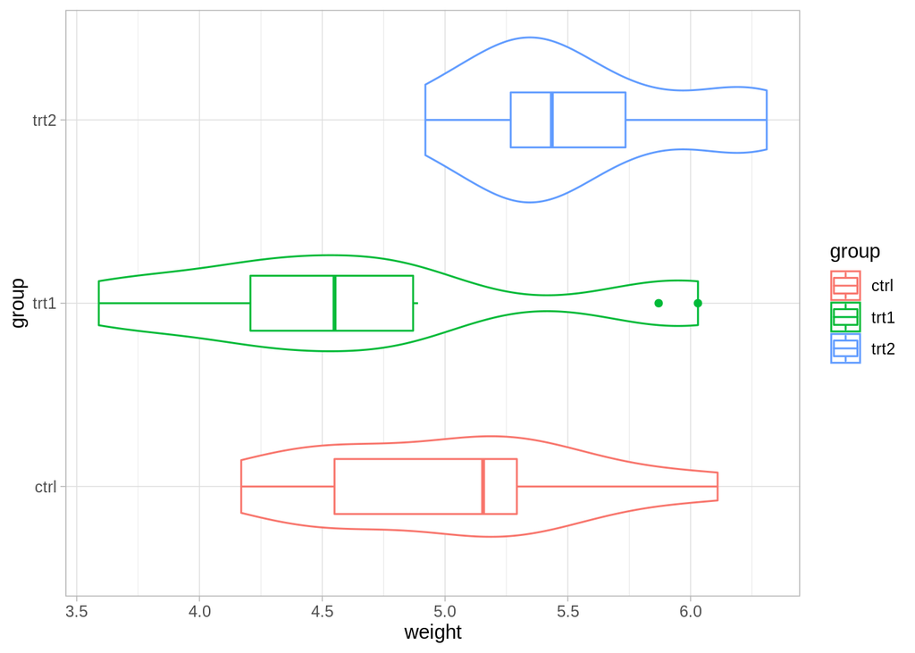

```r
ggplot(PlantGrowth, aes(x=weight, y=group, color = group)) +
  theme_light() +
  geom_violin() +
  geom_boxplot(width=0.3)
```

Por último, você pode escolher colocar o gráfico “de pé”. Nesse caso, basta pedir para que as coodernadas sejam invertidas usando coord_flip().

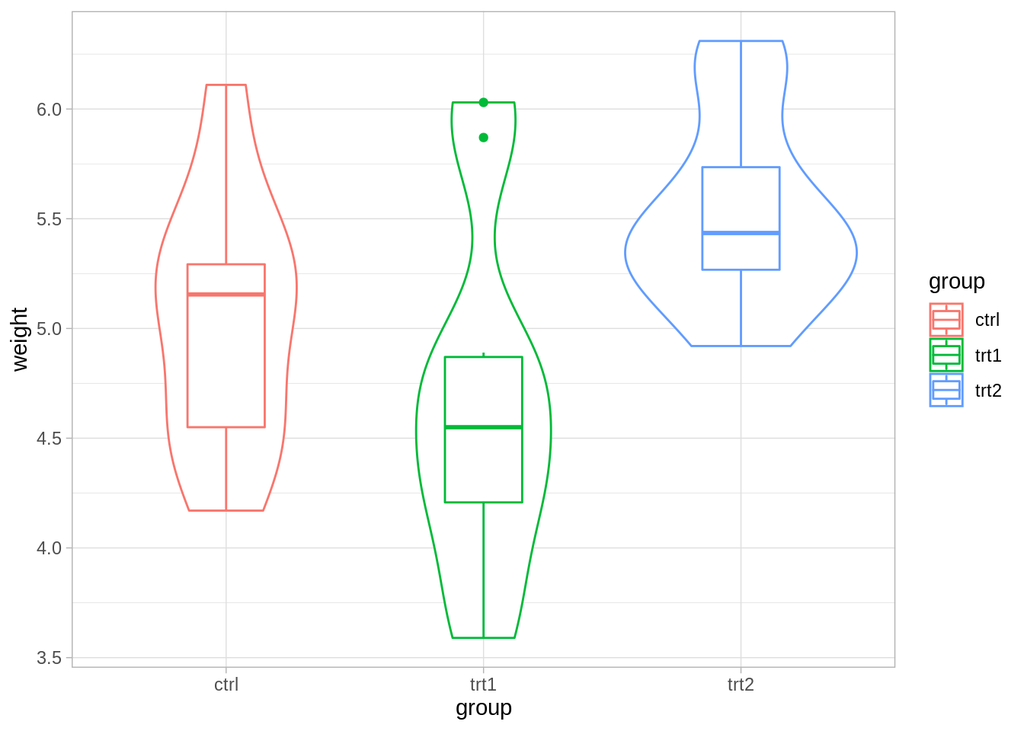

```r
ggplot(PlantGrowth, aes(x=weight, y=group, color = group)) +
  theme_light() +
  geom_violin() +
  geom_boxplot(width=0.3) +
  coord_flip()
```

## Insect Sprays

Podemos fazer a mesma coisa usando o dataset InsectSprays.

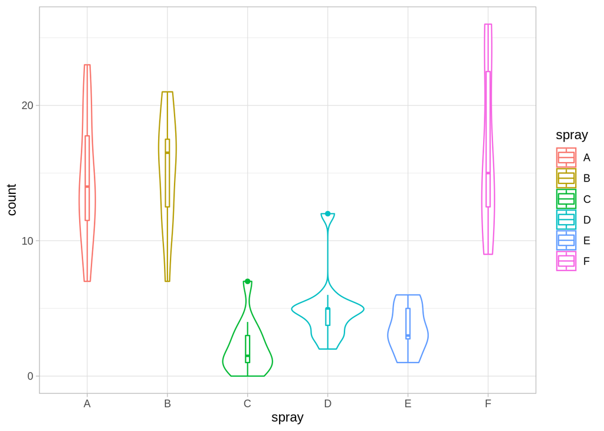

```r
ggplot(InsectSprays, aes(x=spray, y=count, color = spray)) +
  theme_light() +
  geom_violin() +
  geom_boxplot(width=0.05)
```